# Assignment 2

Kari Roynesdal

9/13/2020

```r
library(tidycensus)
library(tidyverse)
library(ggplot2)
library(extrafont)
library(extrafontdb)
loadfonts(device = "win")
```

```r
hh_vars_2018 <- pums_variables %>%
  distinct(year, survey, var_code,
           var_label, data_type, level) %>%
  filter(level == "housing", year == 2018, survey == "acs1")
```

```r
area_vars_2018 <- load_variables(2018, "acs1")
```

```r
area_vars_2010 <- load_variables(2010, "sf1")
```

# Load Variables

I am interested in looking at the following variables:

1. Whether the tract is urban or rural (categorical)
2. The percent of white owner-occupied households (continuous)
3. The majority racial/ethnic identity (categorical)
4. The percent of female residents (continuous)
5. The population of the tract (continuous)
6. The median age of residents (continuous)

I am using 2010 census data for county level census tracts in Suffolk county in Massachusetts.

```r
vars <- c(tot_hh = "H001001",
          tot_urban_hh = "H002002",
         tot_own_hh = "H016002",
         tot_whiteown_hh = "H016A002",
         tot_sex = "P012001",
         tot_female = "P012026",
         tot_pop = "P003001",
         nh_white_pop = "P005003",
         nh_black_pop = "P005004",
         nh_asian_pop = "P005006",
         hispanic_pop = "P005010",
         med_age = "P013001")

Suffolk_tracts <- get_decennial(geography = "tract", variables = vars,
                           state = "MA", county = "Suffolk",
                           output = "wide") %>%
  mutate(urban = (tot_urban_hh == tot_hh) ,
         pct_whiteown = tot_whiteown_hh / tot_own_hh,
         pct_own = tot_own_hh / tot_hh,
         pct_female = tot_female / tot_sex,
         majority_race_eth = case_when(
           nh_white_pop / tot_pop > 0.5 ~ "nh_white",
           nh_black_pop / tot_pop > 0.5 ~ "nh_black",
           nh_asian_pop / tot_pop > 0.5 ~ "nh_asian",
           hispanic_pop / tot_pop > 0.5 ~ "hispanic",
           (nh_white_pop + nh_black_pop + nh_asian_pop + hispanic_pop) /
             tot_pop < 0.5 ~ "other",
           TRUE ~ "None")) %>%
  filter(tot_pop > 0, tot_hh > 0) %>%
  select(GEOID, urban, majority_race_eth,
         pct_whiteown, pct_own, pct_female, tot_pop, med_age)
```

```
## Using Census Summary File 1
```

# Scatterplot

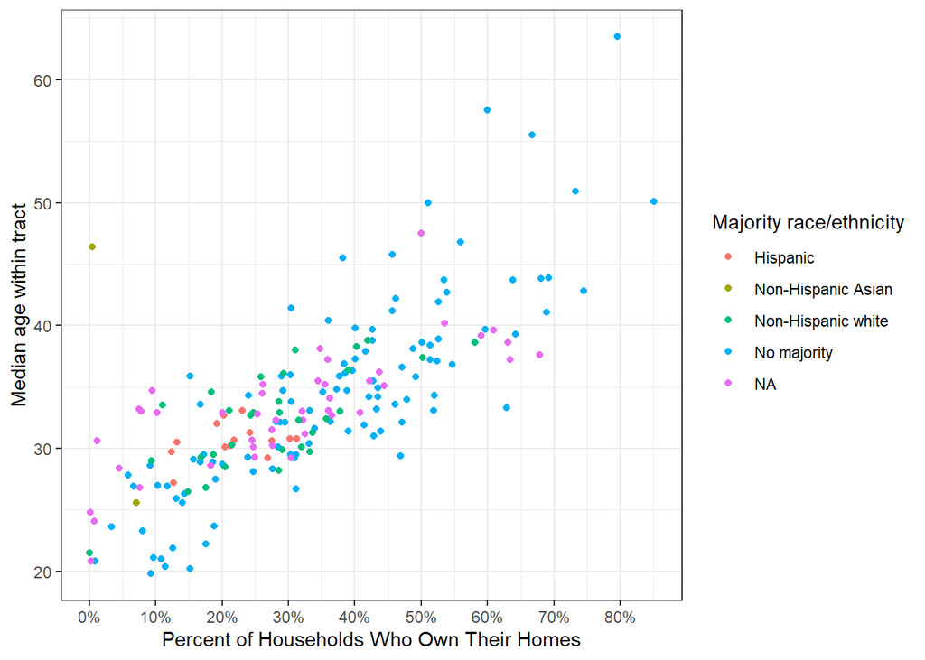

```r
ggplot(Suffolk_tracts,
       aes(x = pct_own,
           y = med_age,
           color = majority_race_eth)) +
  geom_point() +
  scale_x_continuous(name = "Percent of Households Who Own Their Homes",
                     breaks = seq(0, 1, by = 0.1),
                     labels = paste(seq(0, 100, by = 10), "%", sep = "")) +
  scale_y_continuous(name = "Median age within tract",
                     breaks = seq(10, 80, by = 10)) +
  scale_color_discrete(name = "Majority race/ethnicity",
                       labels = c("Hispanic",
                                  "Non-Hispanic Asian",
                                  "Non-Hispanic white",
                                  "No majority")) +
    theme(plot.title = element_text(family = "Garamond",
                             size = 20),
        axis.title = element_text(family = "Garamond"),
        axis.text = element_text(family = "Arial",
                             size = 5),
        legend.title = element_text(family = "Garamond", face = "bold"),
        legend.text = element_text(family = "Garamond" )) +
  theme_bw()
```

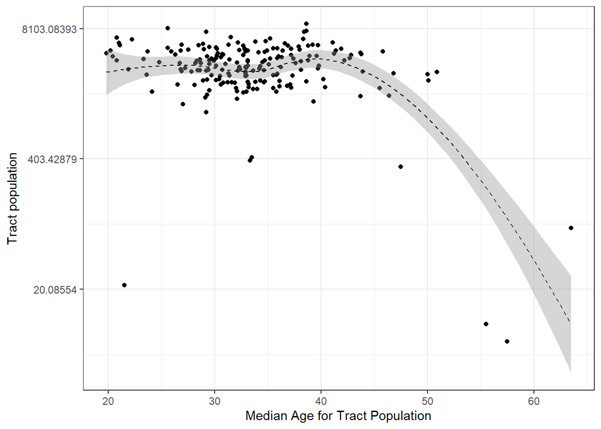

```r
ggplot(Suffolk_tracts,
       aes(x = med_age,
           y = tot_pop)) +
  geom_point() +
  stat_smooth(color = "black", linetype = 2, size = 0.5) +
  scale_x_continuous(name = "Median Age for Tract Population") +
  scale_y_continuous(name = "Tract population",
                     trans = "log") +
  theme(plot.title = element_text(family = "Garamond",
                             size = 20),
        axis.title = element_text(family = "Garamond"),
        axis.text = element_text(family = "Arial",
                             size = 8),
        legend.title = element_text(family = "Garamond", face = "bold"),
        legend.text = element_text(family = "Garamond" )) +
  theme_bw()
```

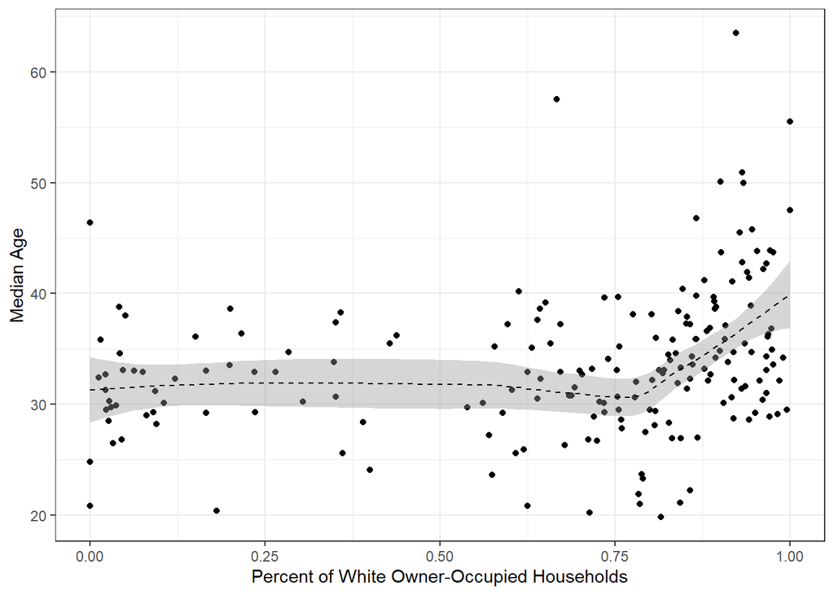

```r
ggplot(Suffolk_tracts,
       aes(x = pct_whiteown,
           y = med_age)) +
  geom_point() +
  stat_smooth(color = "black", linetype = 2, size = 0.5) +
  scale_x_continuous(name = "Percent of White Owner-Occupied Households") +
  scale_y_continuous(name = "Median Age") +
  theme(plot.title = element_text(family = "Garamond",
                             size = 20),
        axis.title = element_text(family = "Garamond"),
        axis.text = element_text(family = "Arial",
                             size = 6),
        legend.title = element_text(family = "Garamond", face = "bold"),
        legend.text = element_text(family = "Garamond" )) +
theme_bw()
```

# Box Plot

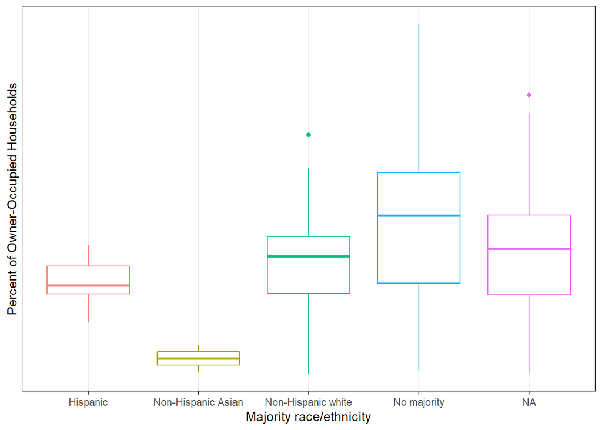

```r
ggplot(Suffolk_tracts,
       aes(x = majority_race_eth,
           y = pct_own,
           color = majority_race_eth)) +
  geom_boxplot() +
  scale_x_discrete(name = "Majority race/ethnicity",
                       labels = c("Hispanic",
                                  "Non-Hispanic Asian",
                                  "Non-Hispanic white",
                                  "No majority")) +
  scale_y_continuous(name = "Percent of Owner-Occupied Households",
                     breaks = seq(10, 80, by = 10)) +
  theme(plot.title = element_text(family = "Garamond",
                             size = 20),
        axis.title = element_text(family = "Garamond"),
        axis.text = element_text(family = "Arial",
                             size = 6),) +
  theme_bw() +
  theme(legend.position = "hide")
```

# Categorical Variables

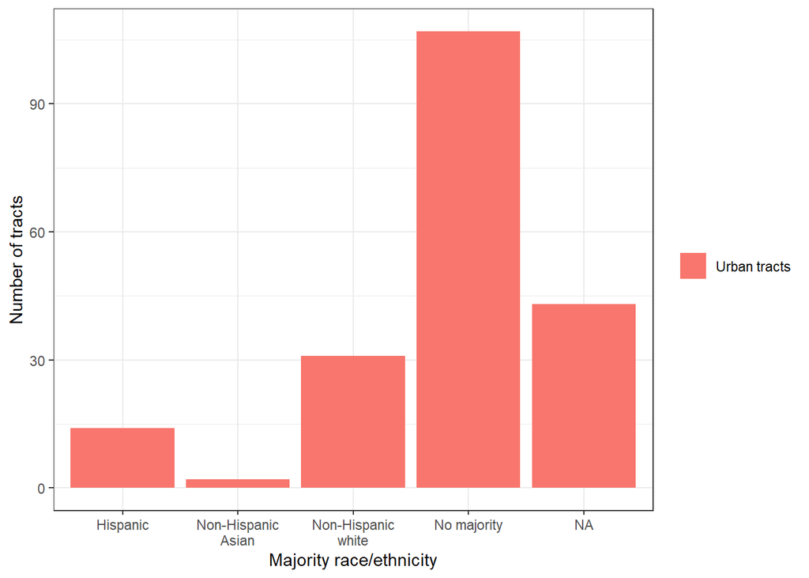

```r
ggplot(Suffolk_tracts, aes(x = majority_race_eth, fill = urban)) +
  geom_bar(position = "dodge") +
  scale_y_continuous(name = "Number of tracts") +
  scale_x_discrete(name = "Majority race/ethnicity",
                       labels = c("Hispanic",
                                  "Non-Hispanic\nAsian",
                                  "Non-Hispanic\nwhite",
                                  "No majority")) +
  scale_fill_discrete(name = element_blank(),
                        labels = c("Urban tracts",
                                   "Rural tracts")) +
  theme(plot.title = element_text(family = "Garamond",
                             size = 20),
        axis.title = element_text(family = "Garamond"),
        axis.text = element_text(family = "Arial",
                             size = 6),
        legend.title = element_text(family = "Garamond", face = "bold"),
        legend.text = element_text(family = "Garamond" )) +
  theme_bw()
```

# Analyze Distributions of Continuous Variables

Percent of White Owner-Occupied Households

```r
pct_whiteown_summary <- summary(Suffolk_tracts$pct_whiteown)
```

```r
pct_whiteown_summary
```

```
##    Min. 1st Qu.  Median    Mean 3rd Qu.    Max.    NA's
##  0.0000  0.5682  0.7870  0.6631  0.8965  1.0000       1
```

Standard Deviation

```r
sd(Suffolk_tracts$pct_whiteown, na.rm = TRUE)
```

```
## [1] 0.3122364
```

95% Confidence Interval

```r
conf_int <- t.test(Suffolk_tracts$pct_whiteown)
```

```r
conf_int
```

```
##
##  One Sample t-test
##
## data:  Suffolk_tracts$pct_whiteown
## t = 29.73, df = 195, p-value < 2.2e-16
## alternative hypothesis: true mean is not equal to 0
## 95 percent confidence interval:
##  0.6190767 0.7070472
## sample estimates:
## mean of x
## 0.6630619
```

Histogram

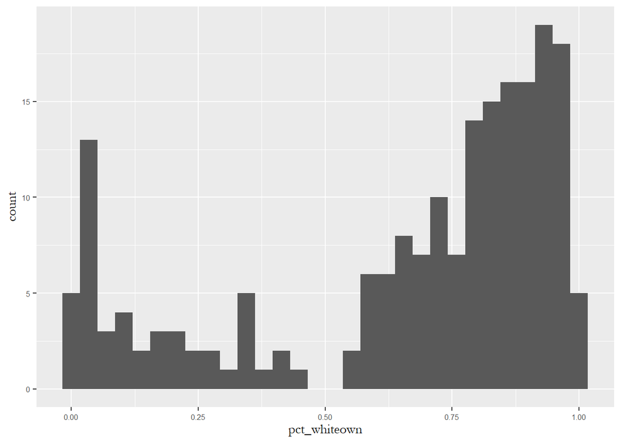

```r
ggplot(Suffolk_tracts, aes(x = pct_whiteown)) +
  theme(plot.title = element_text(family = "Garamond",
                             size = 20),
        axis.title = element_text(family = "Garamond"),
        axis.text = element_text(family = "Arial",
                             size = 6),
        legend.title = element_text(family = "Garamond", face = "bold"),
        legend.text = element_text(family = "Garamond" )) +
  geom_histogram()
```

Percent of Owner-Occupied Households

```r
pct_own_summary <- summary(Suffolk_tracts$pct_own)
```

```r
pct_own_summary
```

```
##    Min. 1st Qu.  Median    Mean 3rd Qu.    Max.
##  0.0000  0.1900  0.3104  0.3248  0.4347  0.8510
```

Standard Deviation

```r
sd(Suffolk_tracts$pct_own)
```

```
## [1] 0.1774669
```

95% Confidence Interval

```r
conf_int <- t.test(Suffolk_tracts$pct_own)
```

```r
conf_int
```

```
##
##  One Sample t-test
##
## data:  Suffolk_tracts$pct_own
## t = 25.687, df = 196, p-value < 2.2e-16
## alternative hypothesis: true mean is not equal to 0
## 95 percent confidence interval:
##  0.2998544 0.3497259
## sample estimates:
## mean of x
## 0.3247902
```

Histogram

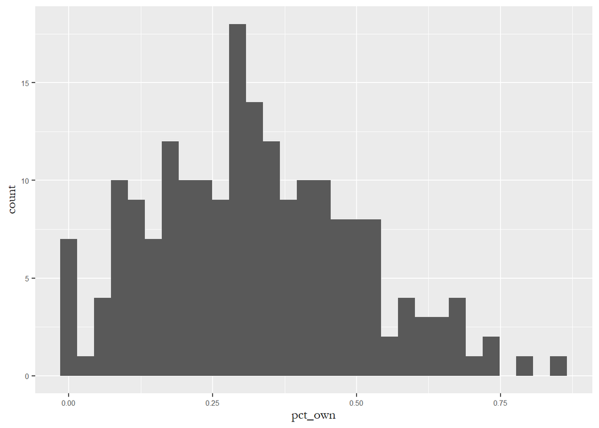

```r
ggplot(Suffolk_tracts, aes(x = pct_own)) +
  theme(plot.title = element_text(family = "Garamond",
                             size = 20),
        axis.title = element_text(family = "Garamond"),
        axis.text = element_text(family = "Arial",
                             size = 6),
        legend.title = element_text(family = "Garamond", face = "bold"),
        legend.text = element_text(family = "Garamond" )) +
  geom_histogram()
```

Total Population

```r
tot_pop_summary <- summary(Suffolk_tracts$tot_pop)
```

```r
tot_pop_summary
```

```
##    Min. 1st Qu.  Median    Mean 3rd Qu.    Max.
##       6    2478    3571    3661    4766    9040
```

Standard Deviation

```r
sd(Suffolk_tracts$tot_pop)
```

```
## [1] 1560.575
```

95% Confidence Interval

```r
conf_int <- t.test(Suffolk_tracts$tot_pop)
```

```r
conf_int
```

```
##
##  One Sample t-test
##
## data:  Suffolk_tracts$tot_pop
## t = 32.929, df = 196, p-value < 2.2e-16
## alternative hypothesis: true mean is not equal to 0
## 95 percent confidence interval:
##  3441.989 3880.539
## sample estimates:
## mean of x
##  3661.264
```

Histogram

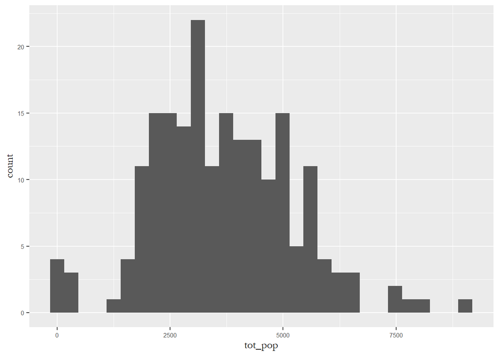

```r
ggplot(Suffolk_tracts, aes(x = tot_pop)) +
  theme(plot.title = element_text(family = "Garamond",
                             size = 20),
        axis.title = element_text(family = "Garamond"),
        axis.text = element_text(family = "Arial",
                             size = 6),
        legend.title = element_text(family = "Garamond", face = "bold"),
        legend.text = element_text(family = "Garamond" )) +
  geom_histogram()
```

This graph shows the total distribution of the total population of Suffolk County, where the average population size per census tract is 3661, with the interquartile range of the population between 2478 and 4766.

Median Age

```r
med_age_summary <- summary(Suffolk_tracts$med_age)
```

```r
med_age_summary
```

```
##    Min. 1st Qu.  Median    Mean 3rd Qu.    Max.
##   19.80   29.50   33.00   33.58   36.90   63.50
```

Standard Deviation

```r
sd(Suffolk_tracts$med_age)
```

```
## [1] 6.71082
```

95% Confidence Interval

```r
conf_int <- t.test(Suffolk_tracts$med_age)
```

```r
conf_int
```

```
##
##  One Sample t-test
##
## data:  Suffolk_tracts$med_age
## t = 70.241, df = 196, p-value < 2.2e-16
## alternative hypothesis: true mean is not equal to 0
## 95 percent confidence interval:
##  32.64133 34.52720
## sample estimates:
## mean of x
##  33.58426
```

Histogram

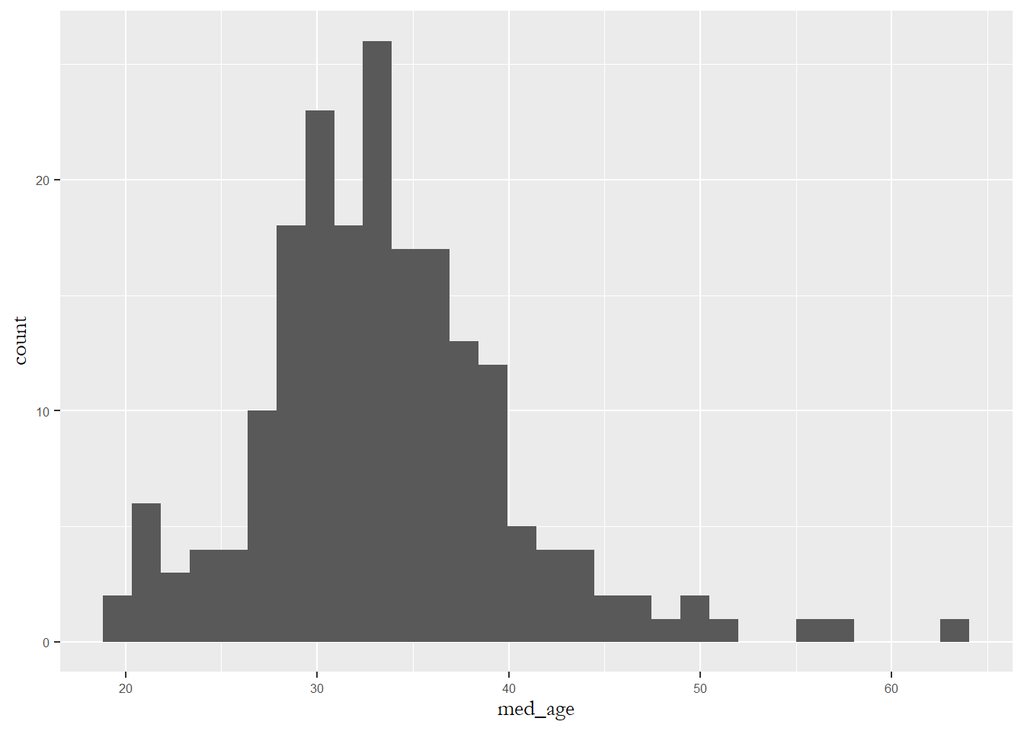

```r
ggplot(Suffolk_tracts, aes(x = med_age)) +
  theme(plot.title = element_text(family = "Garamond",
                             size = 20),
        axis.title = element_text(family = "Garamond"),
        axis.text = element_text(family = "Arial",
                             size = 6),
        legend.title = element_text(family = "Garamond", face = "bold"),
        legend.text = element_text(family = "Garamond" )) +
  geom_histogram()
```

This graph shows the median age in Suffolk County, where the average age and median age are fairly similar at age 33, and the interquartile range between 29.5 and 36.9.

# Categorical Variable Proportions

```r
unique(Suffolk_tracts$majority_race_eth)
```

```
## [1] "nh_white" "hispanic" "None"     "nh_asian" "nh_black"
```

```r
unique(Suffolk_tracts)
```

```
## # A tibble: 197 x 8
##    GEOID  urban majority_race_e~ pct_whiteown pct_own pct_female tot_pop med_age
##    <chr>  <lgl> <chr>                   <dbl>   <dbl>      <dbl>   <dbl>   <dbl>
##  1 25025~ TRUE  nh_white                0.735   0.239      0.470    4254    29.3
##  2 25025~ TRUE  nh_white                0.828   0.276      0.506    3854    28.3
##  3 25025~ TRUE  nh_white                0.800   0.311      0.495    3885    29.5
##  4 25025~ TRUE  nh_white                0.853   0.390      0.491    2740    31.4
##  5 25025~ TRUE  nh_white                0.808   0.469      0.501    3142    29.4
##  6 25025~ TRUE  nh_white                0.720   0.167      0.518    5672    28.9
##  7 25025~ TRUE  nh_white                0.725   0.311      0.479    3648    26.7
##  8 25025~ TRUE  nh_white                0.858   0.176      0.542    6303    22.2
##  9 25025~ TRUE  nh_white                0.807   0.247      0.535    2211    28.1
## 10 25025~ TRUE  nh_white                0.793   0.190      0.572    4985    27.5
## # ... with 187 more rows
```

```r
write_csv(Suffolk_tracts, "Suffolk_tracts.csv")
```